# Notebook

### Web Information Retrieval and Data Mining - Assignment 3

```
Student: Eljasiak, Adam (0965449)
```

#### Answer 1.1, Baseline (4p)

- Dense network, at least 3 layers, shaped like a pyramid
  - Last layer: 10 nodes, sigmoid.
  - Loss: categorical cross-entropy. Metric: accuracy
- No preprocessing, regularization. Get at least 70% accuracy.
- Explain design decisions. Discuss performance.
  - Does it overfit (large/growing gap between loss and val_loss)?

```
By more experiments I found that 2x2048+1024 gives val_acc=80%. Using this network, batch size=32 offers good balance between val_acc=81.5% and training time. Adagrad optimizer and 40 epochs gives val_acc=83%, which is decent considering possible future improvements. (length: 268)

Max val score: 83.43%
```

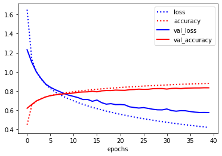

```
Model: "sequential"
_________________________________________________________________
Layer (type)                 Output Shape              Param #
=================================================================
flatten (Flatten)            (None, 3072)              0
_________________________________________________________________
dense (Dense)                (None, 2048)              6293504
_________________________________________________________________
dense_1 (Dense)              (None, 2048)              4196352
_________________________________________________________________
dense_2 (Dense)              (None, 1024)              2098176
_________________________________________________________________
dense_3 (Dense)              (None, 10)                10250
=================================================================
Total params: 12,598,282
Trainable params: 12,598,282
Non-trainable params: 0
_________________________________________________________________
None
def build_model_1_1():
    model = Sequential()
    model.add(Input(shape=(32,32,3)))
    model.add(Flatten())
    model.add(Dense(units=2048, activation='relu'))
    model.add(Dense(units=2048, activation='relu'))
    model.add(Dense(units=1024, activation='relu'))
    model.add(Dense(units=10, activation='softmax'))

    model.compile(optimizer='adagrad', loss='categorical_crossentropy', metrics=['accuracy'])
    return model
```

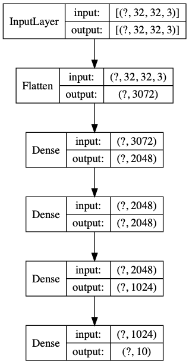

#### Answer 1.2, Preprocess (2p)

- Convert images to greyscale, other preprocessing optional.
  - Input shape should be (32,32,1)
- Explain design decisions. Is it better? Why (not)?
  - Color information is likely not so useful for classification. Greyscale makes the network smaller, less parameters to learn, less likely to overfit.

[output not shown]

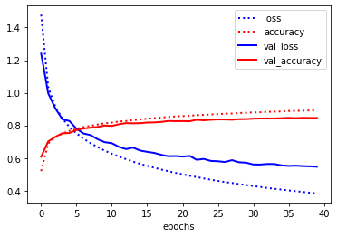

```
Model: "sequential_67"
_________________________________________________________________
Layer (type)                 Output Shape              Param #
=================================================================
flatten_55 (Flatten)         (None, 1024)              0
_________________________________________________________________
dense_271 (Dense)            (None, 2048)              2099200
_________________________________________________________________
dense_272 (Dense)            (None, 2048)              4196352
_________________________________________________________________
dense_273 (Dense)            (None, 1024)              2098176
_________________________________________________________________
dense_274 (Dense)            (None, 10)                10250
=================================================================
Total params: 8,403,978
Trainable params: 8,403,978
Non-trainable params: 0
_________________________________________________________________
None
def build_model_1_2():
    model = Sequential()
    model.add(Input(shape=(32,32,1)))
    model.add(Flatten())
    model.add(Dense(units=2048, activation='relu'))
    model.add(Dense(units=2048, activation='relu'))
    model.add(Dense(units=1024, activation='relu'))
    model.add(Dense(units=10, activation='softmax'))

    model.compile(optimizer='adagrad', loss='categorical_crossentropy', metrics=['accuracy'])
    return model
```

#### Answer 1.3, Tune (4p)

- Regularize the model. What works best?
  - Should consider batch normalization, dropout, l1/l2 regularization (or Nesterov)
- Tune other hyperparameters (e.g. learning rate, batch size,...) as you see fit.
  - At least consider tuning learning rate, ideally also momentum, decay, other optimizers
- Explain your findings and final design decisions. Discuss the results.
  - Should be better, at least it shouldn't overfit

[output not shown]

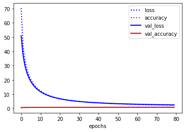

```
def build_model_1_3():
    model = Sequential()

    model.add(Input(shape=(32, 32, 1)))
    model.add(Flatten())

    model.add(Dense(units=2048, activation='relu', kernel_initializer='he_normal', kernel_regularizer=regularizers.l1_l2(0.0001)))
    model.add(BatchNormalization())
    model.add(Dropout(0.25))

    model.add(Dense(units=2048, activation='relu', kernel_initializer='he_normal', kernel_regularizer=regularizers.l1_l2(0.0001)))
    model.add(BatchNormalization())
    model.add(Dropout(0.25))

    model.add(Dense(units=1024, activation='relu', kernel_initializer='he_normal', kernel_regularizer=regularizers.l1_l2(0.0001)))
    model.add(BatchNormalization())

    model.add(Dense(units=10, activation='softmax', kernel_initializer='he_normal', kernel_regularizer=regularizers.l1_l2(0.0001)))

    model.compile(optimizer='adagrad', loss='categorical_crossentropy', metrics=['accuracy'])
    return model
```

#### Answer 2.1, ConvNet (7p)

- Build a sequential ConvNet, get at least 90% accuracy.
  - Conv2D layers, input shape (32,32,1)
  - Consider using blocks of Conv2D layers with maxpooling in between
  - Use zero-padding in Conv2D layers because the images are small
  - At least one dense hidden layer and dense output layer (sigmoid)
  - Consider adding batch normalization, dropout
  - Consider small dropout rates in beginning, larger dropout rates later in network
  - Consider other optimizers and tuning learning rate, momentum,...
- Explain what you did and why (800 chars). Is it working well?
  - Should be quite elaborate and sensible

[output not shown]

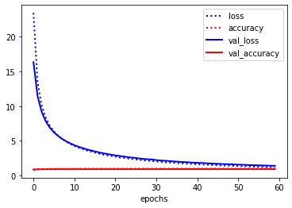

```
Model: "sequential_7"
_________________________________________________________________
Layer (type)                 Output Shape              Param #
=================================================================
conv2d_16 (Conv2D)           (None, 32, 32, 128)       1280
_________________________________________________________________
batch_normalization_23 (Batc (None, 32, 32, 128)       512
_________________________________________________________________
conv2d_17 (Conv2D)           (None, 32, 32, 128)       147584
_________________________________________________________________
max_pooling2d_8 (MaxPooling2 (None, 16, 16, 128)       0
_________________________________________________________________
batch_normalization_24 (Batc (None, 16, 16, 128)       512
_________________________________________________________________
conv2d_18 (Conv2D)           (None, 16, 16, 256)       295168
_________________________________________________________________
batch_normalization_25 (Batc (None, 16, 16, 256)       1024
_________________________________________________________________
conv2d_19 (Conv2D)           (None, 16, 16, 256)       590080
_________________________________________________________________
max_pooling2d_9 (MaxPooling2 (None, 8, 8, 256)         0
_________________________________________________________________
batch_normalization_26 (Batc (None, 8, 8, 256)         1024
_________________________________________________________________
flatten_7 (Flatten)          (None, 16384)             0
_________________________________________________________________
dense_22 (Dense)             (None, 512)               8389120
_________________________________________________________________
dense_23 (Dense)             (None, 128)               65664
_________________________________________________________________
batch_normalization_27 (Batc (None, 128)               512
_________________________________________________________________
dense_24 (Dense)             (None, 10)                1290
=================================================================
Total params: 9,493,770
Trainable params: 9,491,978
Non-trainable params: 1,792
_________________________________________________________________
None
def build_model_2_1():
```

[output cut: 9 more lines]

```
    model.add(Conv2D(filters=256, kernel_size=(3, 3), activation='relu', kernel_initializer='he_normal', kernel_regularizer=regularizers.l1_l2(0.0001), padding='same'))
    model.add(BatchNormalization())
    model.add(Conv2D(filters=256, kernel_size=(3, 3), activation='relu', kernel_initializer='he_normal', kernel_regularizer=regularizers.l1_l2(0.0001), padding='same'))
    model.add(MaxPool2D(pool_size=(2, 2)))
    model.add(BatchNormalization())

    model.add(Flatten())

    model.add(Dense(units=512, activation='relu', kernel_initializer='he_normal', kernel_regularizer=regularizers.l1_l2(0.0001)))
    model.add(Dense(units=128, activation='relu', kernel_initializer='he_normal', kernel_regularizer=regularizers.l1_l2(0.0001)))
    model.add(BatchNormalization())
    model.add(Dense(units=10, activation='softmax', kernel_initializer='he_normal', kernel_regularizer=regularizers.l1_l2(0.0001)))

    model.compile(optimizer='adagrad', loss='categorical_crossentropy', metrics=['accuracy'])
    return model
```

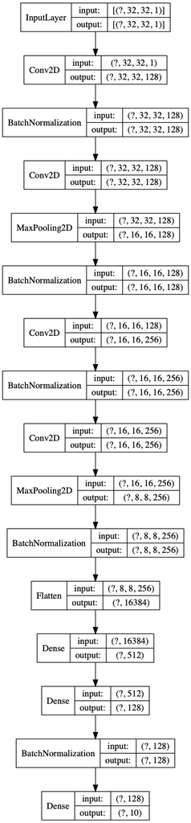

#### Answer 2.2, Data Augmentation (3p)

- Augment the preprocessed training data.
  - Use small variations (small shifts up-down, left-right) of flips becasue the images are small
  - Large shifts and rotations distort the image too much
- Explain what you did and why. Discuss the performance of the model.

[output not shown]

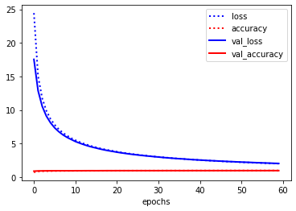

```
train_gen = ImageDataGenerator(rotation_range=20,
                              width_shift_range=0.1,
                              height_shift_range=0.1,
                              fill_mode='nearest')
```

#### Answer 3.1, Misclassifications (2p)

[output not shown]

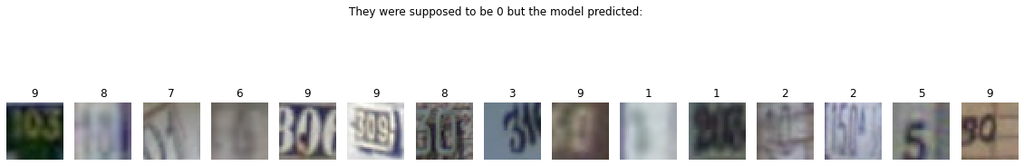

#### Answer 3.2, Activations (4p)

- Retrieve and visualize the activations for one example
- For every filter for different convolutional layers (at different depths in the network).
- Give an explanation. Is your model indeed learning something useful?
  - Should detect edges etc in first layers, higher-order object (e.g. interesting regions) in deeper layers.

[output not shown]

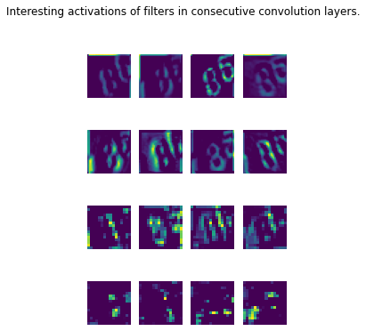

#### Answer 3.3, Class activation map (4p)

- Show a class activation map for your last convolutional layer
- Superimpose the activation map over the image, or plot side by side
  - Should make sense, detect interesting regions to classify the number

```
8
```

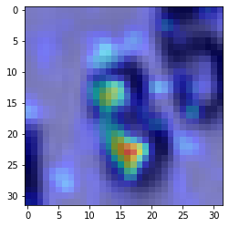

```
def plot_activation_map():
    example = np.expand_dims(pre_X_test[example_to_inspect], 0)
    model = load_model(os.path.join(base_dir, 'model_2_2.h5'))

    predicted_class = np.argmax(model.predict(example))
    print(predicted_class + 1)

    last_conv_layer = model.layers[7]
    output_layer = model.output

    gradients = K.gradients(output_layer[:, predicted_class], last_conv_layer.output)[0]
    pooled_grads = K.mean(gradients, axis=(0, 1, 2))
    iterate = K.function([model.input], [pooled_grads, last_conv_layer.output[0]])
    pooled_grads_value, conv_layer_output_value = iterate([example])


    for i in range(last_conv_layer.filters):
        conv_layer_output_value[:, :, i] *= pooled_grads_value[i]

    heatmap = np.mean(conv_layer_output_value, axis=-1)
    heatmap = np.maximum(heatmap, 0)
    heatmap /= np.max(heatmap)
    heatmap = (heatmap * 255).astype('uint8')
    heatmap = cv2.resize(heatmap, (32, 32))
    heatmap = cv2.applyColorMap(heatmap, cv2.COLORMAP_JET)
    heatmap = cv2.cvtColor(heatmap, cv2.COLOR_BGR2RGB)


    plt.imshow(heatmap, alpha=0.5)
```

#### Answer 4.1, Fast feature extraction (5p)

- Import the VGG16 model, pretrained on ImageNet
- Freeze convolutional base, adds a dense layer
- Consider unfreezing the last few convolutional layers and evaluate whether that works better
  - Check if they do. It is very likely to help.
- Discuss the observed performance
  - Should get around 80% accuracy

[output not shown]

[figure not shown]

```
Model: "sequential_3"
_________________________________________________________________
Layer (type)                 Output Shape              Param #
=================================================================
vgg16 (Model)                (None, 1, 1, 512)         14714688
_________________________________________________________________
flatten_3 (Flatten)          (None, 512)               0
_________________________________________________________________
dense_5 (Dense)              (None, 128)               65664
_________________________________________________________________
batch_normalization_3 (Batch (None, 128)               512
_________________________________________________________________
dense_6 (Dense)              (None, 10)                1290
=================================================================
Total params: 14,782,154
Trainable params: 7,146,634
Non-trainable params: 7,635,520
_________________________________________________________________
None
def build_model_4_1():

    model = Sequential()
    vgg16 = VGG16(include_top=False, weights='imagenet', input_shape=(32, 32, 3))

    # The last one is max pooling so start from -2 to see any effects. Next max pooling is at -5
    for l in vgg16.layers[:-4]:
        l.trainable = False

    for l in vgg16.layers:
        print(l.name, l.input.shape, 'Trainable:', l.trainable)

    model.add(vgg16)
    model.add(Flatten())
    model.add(Dense(units=128, activation='relu', kernel_initializer='he_normal', kernel_regularizer=regularizers.l1_l2(0.0001)))
    model.add(BatchNormalization())
    model.add(Dense(units=10, activation='softmax', kernel_initializer='he_normal', kernel_regularizer=regularizers.l1_l2(0.0001)))

    model.compile(loss='categorical_crossentropy', optimizer=RMSprop(lr=0.00001), metrics=['accuracy'])
    model.summary()
    return model
```

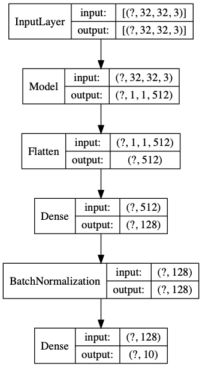

#### Answer 4.2, Embeddings (5p)

- Generate embeddings with the trained convolutional part of model_4_1 (without the dense layer)
- Embed the training and test data and store them to disk
- Build and evaluate a pipeline on the embedded data
  - Check if pipeline makes sense (e.g. use models that can handle many dimensions)
- Describe what you did and what you observed (max 800 chars).
  - Consider different models, preprocessing, tuning, etc.
  - Check performance (see original Submission.html) when in doubt. We did not run all the evaluations because it takes too long, and the output is ill-defined.

[output not shown]

```
Running time: 16.72 seconds
Last modified: May 26, 2020
scikit-learn version: 0.23.1
```